# Assignment 1

Darren Chan

```r
# Based on code by Ruth Isserlin (2020), BCB420 Lecture 4 - Exploring the data and basics of Normalization

# Load the data if already downloaded
if (file.exists("GSE120891_table.RData")) {
  load("GSE120891_table.RData")
} else {
  # Otherwise, download it from the database
  #gse <- GEOquery::getGEO("GSE120891",GSEMatrix=FALSE)
  sfiles <- GEOquery::getGEOSuppFiles('GSE120891')
  fnames <- rownames(sfiles)

  # we only want the counts file
  raw_counts_table <- read.delim(fnames[grep("counts", fnames)], header=TRUE, check.names = FALSE)
  save(raw_counts_table, file = "GSE120891_table.RData")
}

head(raw_counts_table)
```

|  |  | AD169_MRC5_1 | AD169_MRC5_2 | Ad5_1 | FIX_MRC5_1 | FIX_MRC5_2 | Mock_24h_1 | Mock_24h_2 | Mock_ARPE19_1 | Mock_ARPE19_2 | Mock_9h_1 | Mock_9h_2 | Mock_MRC5_1 | Mock_MRC5_2 | Ad5_2 | HSV_1 | HSV_2 | NT-LNA_Mock_1 | HSII-LNA_Mock_1 | NT-LNA_HCMV_1 | HSII-LNA_HCMV_1 | NT-LNA_Mock_2 | HSII-LNA_Mock_2 | NT-LNA_HCMV_2 | HSII-LNA_HCMV_2 | TB40e_ARPE19_1 | TB40e_ARPE19_1 | TB40e_MRC5_1 | TB40e_MRC5_1 | … |
| --- | --- | --- | --- | --- | --- | --- | --- | --- | --- | --- | --- | --- | --- | --- | --- | --- | --- | --- | --- | --- | --- | --- | --- | --- | --- | --- | --- | --- | --- | --- |
| 1 | ENSG00000223972.5 | 0 | 0 | 0 | 0 | 0 | 0 | 0 | 0 | 0 | 0 | 0 | 0 | 0 | 0 | 0 | 0 | 0 | 1 | 1 | 0 | 0 | 0 | 0 | 0 | 0 | 0 | 0 | 0 | … |
| 2 | ENSG00000227232.5 | 24 | 31 | 14 | 35 | 24 | 14 | 22 | 17 | 21 | 11 | 16 | 25 | 18 | 2 | 3 | 4 | 54 | 69 | 56 | 60 | 36 | 49 | 49 | 42 | 18 | 21 | 36 | 23 | … |
| 3 | ENSG00000278267.1 | 3 | 5 | 1 | 6 | 5 | 3 | 2 | 5 | 8 | 4 | 1 | 8 | 9 | 1 | 0 | 0 | 9 | 15 | 13 | 12 | 9 | 9 | 10 | 4 | 4 | 5 | 5 | 4 | … |
| 4 | ENSG00000243485.3 | 0 | 0 | 0 | 0 | 0 | 0 | 0 | 0 | 0 | 0 | 0 | 1 | 0 | 0 | 0 | 0 | 1 | 0 | 0 | 0 | 0 | 0 | 0 | 0 | 0 | 0 | 0 | 0 | … |
| 5 | ENSG00000274890.1 | 0 | 0 | 0 | 0 | 0 | 0 | 0 | 0 | 0 | 0 | 0 | 0 | 0 | 0 | 0 | 0 | 0 | 0 | 0 | 0 | 0 | 0 | 0 | 0 | 0 | 0 | 0 | 0 | … |
| 6 | ENSG00000237613.2 | 0 | 0 | 0 | 0 | 0 | 0 | 0 | 0 | 0 | 0 | 0 | 0 | 0 | 0 | 0 | 0 | 0 | 0 | 0 | 0 | 0 | 0 | 0 | 0 | 0 | 0 | 0 | 0 | … |

The dataset that I chose is GSE120891 (Differential expression of genes in fibroblasts and epithelial cells infected with dsDNA viruses), which consists of RNA-seq data for fibroblast and epithelial cells that have either been infected by a mock virus (control condition) or infected with one of three different types of viruses (HCMV/human cytomegalovirus/human betaherpesvirus 5 with three different strains TB40, FIX, and AD169; HSV1/herpes simplex virus; and Ad5/adenovirus serotype 5) in the test conditions.

This dataset is of interest to me because it explores how cells change when exposed to viruses - either to try and fight off the invader or because of the effects of the virus within the cell as it aims to reproduce. This sort of data could hint at what sorts of molecular defenses the cell has - with potential applications in trying to boost the body’s natural immunity - as well as what sorts of pathways viruses trigger to trick the cell into accepting its DNA and taking over.

```r
# Convert from counts to counts per million
cpms <- edgeR::cpm(raw_counts_table[, 2:dim(raw_counts_table)[2]])

# Get rid of low counts to clean - need at least 2 samples with 1 count per million
keep <- rowSums(cpms > 1) >= 2
counts_filtered <- raw_counts_table[keep, ]

# Get the number of removed samples
numRemoved <- nrow(raw_counts_table) - nrow(counts_filtered)
```

A total of 41763 genes were removed from the data set with a counts per million measurement too low to be reliably analyzed.

```r
# Set Ensembl gene IDs (without version numbers) as row names
counts_table <- counts_filtered
rownames(counts_table) <- gsub("\\..*", "", counts_filtered[, 1])
colnames(counts_table)[1] <- "ensembl_gene_id_version"

# Load Ensembl mart
ensembl <- biomaRt::useEnsembl(biomart = "ensembl", mirror = "useast")
ensembl <- biomaRt::useDataset("hsapiens_gene_ensembl",mart=ensembl)

# Map to HUGO gene symbols
conversion_stash <- "GSE120891_id_conversion.rds"
if(file.exists(conversion_stash)){
  GSE120891_id_conversion <- readRDS(conversion_stash)
} else {
  GSE120891_id_conversion <- biomaRt::getBM(attributes = c("ensembl_gene_id","hgnc_symbol"),
                              filters = c("ensembl_gene_id"),
                              values = rownames(counts_table),
                              mart = ensembl)
  saveRDS(GSE120891_id_conversion, conversion_stash)
}

counts_annot <- merge(GSE120891_id_conversion, counts_table, by.x = 1, by.y = 0, all.y=TRUE)

# Check for and deal with missing gene symbols
non_missing_hgnc_rows <- counts_annot[which(!is.na(counts_annot$hgnc_symbol) & counts_annot$hgnc_symbol != ""), ]
missing_hgnc_rows <- counts_annot[which(is.na(counts_annot$hgnc_symbol) | counts_annot$hgnc_symbol == ""), ]
rownames(missing_hgnc_rows) <- missing_hgnc_rows[, 1]
num_missing_hgnc <- nrow(missing_hgnc_rows)

# Load older Ensembl mart version
grch37 <- biomaRt::useEnsembl(biomart="ensembl", GRCh=37)
grch37 <- biomaRt::useDataset("hsapiens_gene_ensembl",mart=grch37)

# Try to map missing genes with the older ensembl version
grch37_conversion_stash <- "grch37_GSE120891_id_conversion.rds"
if(file.exists(grch37_conversion_stash)){
  grch37_GSE120891_id_conversion <- readRDS(grch37_conversion_stash)
} else {
  grch37_GSE120891_id_conversion <- biomaRt::getBM(attributes = c("ensembl_gene_id","hgnc_symbol"),
                              filters = c("ensembl_gene_id"),
                              values = missing_hgnc_rows$ensembl_gene_id,
                              mart = grch37)
  saveRDS(grch37_GSE120891_id_conversion, grch37_conversion_stash)
}

# Filter out the rows that have been newly matched and add them to the mapped table
missing_hgnc_rows <- merge(grch37_GSE120891_id_conversion, missing_hgnc_rows[, -2], by.x = 1, by.y = 1, all.y=TRUE)
old_annot_hgnc_rows <- missing_hgnc_rows[which(!is.na(missing_hgnc_rows$hgnc_symbol) & missing_hgnc_rows$hgnc_symbol != ""),  ]
missing_hgnc_rows <- missing_hgnc_rows[which(is.na(missing_hgnc_rows$hgnc_symbol) | missing_hgnc_rows$hgnc_symbol == ""), ]
non_missing_hgnc_rows <- rbind(non_missing_hgnc_rows, old_annot_hgnc_rows)
num_old_annot_hgnc <- nrow(old_annot_hgnc_rows)

# Try to identify remaining missing genes by gene name
grch37_name_conversion_stash <- "grch37_name_GSE120891_id_conversion.rds"
if(file.exists(grch37_name_conversion_stash)){
  grch37_name_GSE120891_id_conversion <- readRDS(grch37_name_conversion_stash)
} else {
  grch37_name_GSE120891_id_conversion <- biomaRt::getBM(attributes = c("ensembl_gene_id","external_gene_name"),
                              filters = c("ensembl_gene_id"),
                              values = missing_hgnc_rows$ensembl_gene_id,
                              mart = grch37)
  saveRDS(grch37_name_GSE120891_id_conversion, grch37_name_conversion_stash)
}

# Use the HGNCHelper vignette for this
if (! requireNamespace("HGNChelper", quietly = TRUE)) {
  BiocManager::install("HGNChelper")
}

HGNChelperNames <- HGNChelper::checkGeneSymbols(grch37_name_GSE120891_id_conversion$external_gene_name)
HGNChelperNames <- HGNChelperNames[which(!is.na(HGNChelperNames$Suggested.Symbol)), ]

grch37_name_conversion <- merge(grch37_name_GSE120891_id_conversion, HGNChelperNames[, -2], by.x = 2, by.y = 1)
colnames(grch37_name_conversion)[3] <- "hgnc_symbol"
missing_hgnc_rows <- merge(grch37_name_conversion[-1], missing_hgnc_rows[, -2], by.x = 1, by.y = 1, all.y=TRUE)

# Filter out the rows that matched rows
hgnchelper_annot_hgnc_rows <- missing_hgnc_rows[which(!is.na(missing_hgnc_rows$hgnc_symbol)), ]
missing_hgnc_rows <- missing_hgnc_rows[which(is.na(missing_hgnc_rows$hgnc_symbol)), ]
non_missing_hgnc_rows <- rbind(non_missing_hgnc_rows, hgnchelper_annot_hgnc_rows)
num_hgncHelper_rows <- nrow(hgnchelper_annot_hgnc_rows)

# Final gene HGNC mappings
counts_annot <- non_missing_hgnc_rows
head(counts_annot)
```

|  | ensembl_gene_id | hgnc_symbol | ensembl_gene_id_version | AD169_MRC5_1 | AD169_MRC5_2 | Ad5_1 | FIX_MRC5_1 | FIX_MRC5_2 | Mock_24h_1 | Mock_24h_2 | Mock_ARPE19_1 | Mock_ARPE19_2 | Mock_9h_1 | Mock_9h_2 | Mock_MRC5_1 | Mock_MRC5_2 | Ad5_2 | HSV_1 | HSV_2 | NT-LNA_Mock_1 | HSII-LNA_Mock_1 | NT-LNA_HCMV_1 | HSII-LNA_HCMV_1 | NT-LNA_Mock_2 | HSII-LNA_Mock_2 | NT-LNA_HCMV_2 | HSII-LNA_HCMV_2 | TB40e_ARPE19_1 | TB40e_ARPE19_1.1 | … |
| --- | --- | --- | --- | --- | --- | --- | --- | --- | --- | --- | --- | --- | --- | --- | --- | --- | --- | --- | --- | --- | --- | --- | --- | --- | --- | --- | --- | --- | --- | --- |
| 1 | ENSG00000000003 | TSPAN6 | ENSG00000000003.14 | 346 | 378 | 201 | 445 | 344 | 234 | 260 | 585 | 634 | 329 | 252 | 427 | 433 | 82 | 18 | 31 | 245 | 295 | 272 | 285 | 220 | 240 | 233 | 172 | 232 | 371 | … |
| 2 | ENSG00000000419 | DPM1 | ENSG00000000419.12 | 371 | 390 | 602 | 704 | 654 | 367 | 350 | 304 | 345 | 356 | 289 | 388 | 323 | 425 | 200 | 336 | 558 | 601 | 781 | 749 | 571 | 608 | 705 | 648 | 403 | 534 | … |
| 3 | ENSG00000000457 | SCYL3 | ENSG00000000457.13 | 253 | 249 | 56 | 349 | 281 | 121 | 132 | 224 | 220 | 148 | 109 | 239 | 240 | 26 | 42 | 75 | 212 | 267 | 202 | 216 | 183 | 188 | 220 | 173 | 196 | 274 | … |
| 4 | ENSG00000000460 | C1orf112 | ENSG00000000460.16 | 382 | 364 | 110 | 309 | 250 | 219 | 217 | 113 | 124 | 190 | 143 | 207 | 60 | 94 | 54 | 71 | 61 | 84 | 195 | 137 | 95 | 83 | 165 | 74 | 177 | 280 | … |
| 5 | ENSG00000000971 | CFH | ENSG00000000971.15 | 434 | 319 | 628 | 255 | 300 | 626 | 603 | 1171 | 1204 | 716 | 627 | 1123 | 1138 | 284 | 39 | 87 | 489 | 442 | 1278 | 1064 | 487 | 382 | 1189 | 771 | 96 | 311 | … |
| 6 | ENSG00000001036 | FUCA2 | ENSG00000001036.13 | 1169 | 1219 | 1033 | 1460 | 1342 | 1036 | 949 | 940 | 955 | 953 | 704 | 1461 | 1248 | 771 | 31 | 61 | 1672 | 2081 | 2289 | 2340 | 1677 | 2119 | 2121 | 1773 | 797 | 1144 | … |

```r
# Check for and non-unique genes (HGNC symbols)
duplicated_hgnc <- counts_annot[duplicated(counts_annot$hgnc_symbol), ]
num_duplicated_hgnc <- nrow(duplicated_hgnc)

real_duplicated_hgnc <- duplicated_hgnc[which(!is.na(duplicated_hgnc$hgnc_symbol) & duplicated_hgnc$hgnc_symbol != ""), ]
num_real_duplicated_hgnc <- nrow(real_duplicated_hgnc)
duplicated_rows <- counts_annot[counts_annot$hgnc_symbol %in% real_duplicated_hgnc$hgnc_symbol, ]

# Add up duplicate rows
summed_rows_hgnc <- duplicated_rows[!duplicated(duplicated_rows$hgnc_symbol), ]
for (i in seq_along(summed_rows_hgnc[, 1])) {
  summed_rows_hgnc[i, 4:dim(summed_rows_hgnc)[2]] <- colSums(duplicated_rows[duplicated_rows$hgnc_symbol == summed_rows_hgnc$hgnc_symbol[i], 4:dim(duplicated_rows)[2]])
}

nonduplicated_rows <- counts_annot[!(counts_annot$hgnc_symbol %in% real_duplicated_hgnc$hgnc_symbol), ]
final_counts_annot <- rbind(nonduplicated_rows, summed_rows_hgnc)
rownames(final_counts_annot) <- final_counts_annot$hgnc_symbol

head(duplicated_rows)
```

|  | ensembl_gene_id | hgnc_symbol | ensembl_gene_id_version | AD169_MRC5_1 | AD169_MRC5_2 | Ad5_1 | FIX_MRC5_1 | FIX_MRC5_2 | Mock_24h_1 | Mock_24h_2 | Mock_ARPE19_1 | Mock_ARPE19_2 | Mock_9h_1 | Mock_9h_2 | Mock_MRC5_1 | Mock_MRC5_2 | Ad5_2 | HSV_1 | HSV_2 | NT-LNA_Mock_1 | HSII-LNA_Mock_1 | NT-LNA_HCMV_1 | HSII-LNA_HCMV_1 | NT-LNA_Mock_2 | HSII-LNA_Mock_2 | NT-LNA_HCMV_2 | HSII-LNA_HCMV_2 | TB40e_ARPE19_1 | TB40e_ARPE19_1.1 | … |
| --- | --- | --- | --- | --- | --- | --- | --- | --- | --- | --- | --- | --- | --- | --- | --- | --- | --- | --- | --- | --- | --- | --- | --- | --- | --- | --- | --- | --- | --- | --- |
| 219 | ENSG00000010404 | IDS | ENSG00000010404.17 | 224 | 287 | 174 | 382 | 384 | 218 | 241 | 427 | 615 | 392 | 273 | 322 | 328 | 227 | 106 | 225 | 1591 | 1668 | 2226 | 1666 | 1339 | 1039 | 2003 | 1273 | 331 | 497 | … |
| 2837 | ENSG00000106588 | PSMA2 | ENSG00000106588.10 | 99 | 104 | 113 | 92 | 82 | 100 | 116 | 124 | 116 | 101 | 97 | 101 | 72 | 15 | 14 | 27 | 55 | 89 | 89 | 60 | 56 | 60 | 69 | 59 | 62 | 86 | … |
| 4476 | ENSG00000122390 | NAA60 | ENSG00000122390.17 | 125 | 140 | 77 | 237 | 169 | 89 | 89 | 173 | 201 | 106 | 78 | 138 | 121 | 186 | 58 | 134 | 457 | 470 | 467 | 450 | 385 | 383 | 449 | 381 | 150 | 197 | … |
| 4920 | ENSG00000126749 | EMG1 | ENSG00000126749.14 | 303 | 304 | 163 | 423 | 370 | 198 | 158 | 203 | 168 | 229 | 173 | 222 | 144 | 46 | 19 | 37 | 75 | 110 | 158 | 141 | 111 | 112 | 156 | 97 | 226 | 345 | … |
| 7722 | ENSG00000150527 | MIA2 | ENSG00000150527.16 | 29 | 23 | 25 | 50 | 43 | 22 | 29 | 31 | 29 | 35 | 22 | 32 | 22 | 9 | 27 | 47 | 36 | 64 | 37 | 68 | 35 | 52 | 37 | 41 | 40 | 46 | … |
| 14011 | ENSG00000206652 | RNU1-1 | ENSG00000206652.1 | 8 | 4 | 1 | 7 | 6 | 6 | 11 | 12 | 17 | 21 | 10 | 26 | 9 | 2 | 4 | 3 | 10 | 11 | 7 | 11 | 9 | 9 | 13 | 3 | 3 | 11 | … |

```r
# Compute overview statistics
initial_num_genes <- nrow(raw_counts_table)
num_genes_high_cpm <- nrow(counts_filtered)
num_genes_mapped <- nrow(non_missing_hgnc_rows)
num_genes_unique <- nrow(final_counts_annot)
```

Replicates were kept seperate throughout the process and in the final processed data. Since each experimental group only had 2 replicates, combining or averaging them together would not have made much of a difference to the overall size of the data set, and keeping both sets of data preserves more information, particularly if they diverge to a significant extent (with only 2 replicates, we cannot be sure which is the outlier - or if both are).

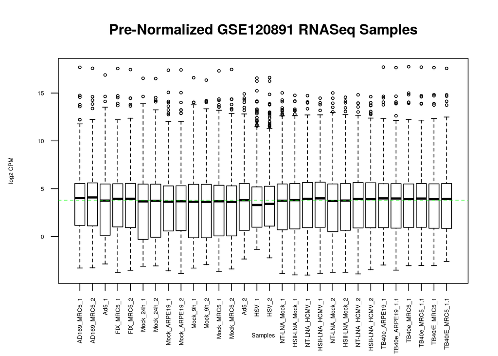

```r
# Draw a box plot of the pre-normalized data
logPreNormData <- log2(edgeR::cpm(final_counts_annot[, 4:dim(final_counts_annot)[2]]))
boxplot(logPreNormData, xlab = "Samples", ylab = "log2 CPM",
        las = 2, cex = 0.5, cex.lab = 0.5,
        cex.axis = 0.5, main = "Pre-Normalized GSE120891 RNASeq Samples")
abline(h = median(apply(logPreNormData, 2, median)), col = "green", lwd = 0.6, lty = "dashed")
```

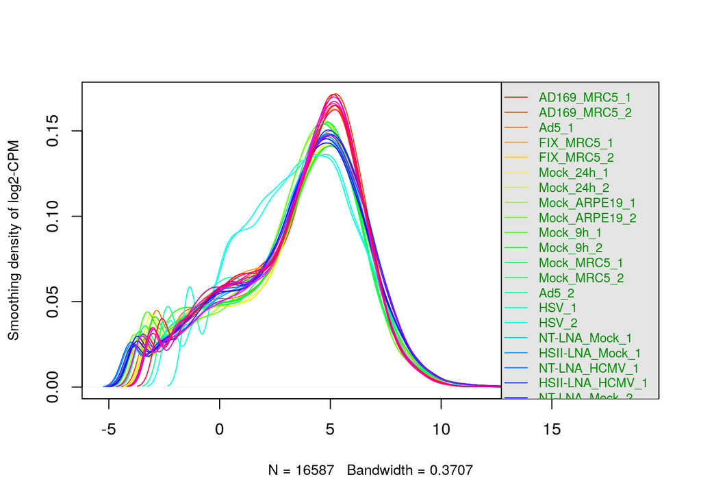

```r
# Draw a density plot of the pre-normalized data
pre_counts_density <- apply(log2(edgeR::cpm(final_counts_annot[, 4:dim(final_counts_annot)[2]])), 2, density)

# calculate the limits across all the samples
xlim <- 0; ylim <- 0
for (i in 1:length(pre_counts_density)) {
  xlim <- range(c(xlim, pre_counts_density[[i]]$x));
  ylim <- range(c(ylim, pre_counts_density[[i]]$y))
}
cols <- rainbow(length(pre_counts_density))
ltys <- rep(1, length(pre_counts_density))
#plot the first density plot to initialize the plot
plot(pre_counts_density[[1]], xlim=xlim, ylim=ylim, type="n",
     ylab="Smoothing density of log2-CPM", main="", cex.lab = 0.85)
#plot each line
for (i in 1:length(pre_counts_density)) lines(pre_counts_density[[i]], col=cols[i], lty=ltys[i])
#create legend
legend("topright", colnames(logPreNormData),
       col=cols, lty=ltys, cex=0.75,
       border ="blue",  text.col = "green4",
       merge = TRUE, bg = "gray90")
```

The box plot and density plots indicate that there isn’t a particularly large amount of variation between the samples as a whole, with medians approximately equal in the boxplots and the density distributions roughly aligned as well. Nevertheless, normalization can still help.

```r
# Perform Normalization
filtered_data_matrix <- as.matrix(final_counts_annot[, 4:dim(final_counts_annot)[2]])
rownames(filtered_data_matrix) <- final_counts_annot$hgnc_symbol
d <- edgeR::DGEList(counts=filtered_data_matrix)
d_normFactors <- edgeR::calcNormFactors(d)
counts_normalized <- as.data.frame(edgeR::cpm(d_normFactors))

head(counts_normalized)
```

|  | AD169_MRC5_1 | AD169_MRC5_2 | Ad5_1 | FIX_MRC5_1 | FIX_MRC5_2 | Mock_24h_1 | Mock_24h_2 | Mock_ARPE19_1 | Mock_ARPE19_2 | Mock_9h_1 | Mock_9h_2 | Mock_MRC5_1 | Mock_MRC5_2 | Ad5_2 | HSV_1 | HSV_2 | NT-LNA_Mock_1 | HSII-LNA_Mock_1 | NT-LNA_HCMV_1 | HSII-LNA_HCMV_1 | NT-LNA_Mock_2 | HSII-LNA_Mock_2 | NT-LNA_HCMV_2 | HSII-LNA_HCMV_2 | TB40e_ARPE19_1 | TB40e_ARPE19_1.1 | TB40e_MRC5_1 | TB40e_MRC5_1.1 | TB40/E_MRC5_1 | … |
| --- | --- | --- | --- | --- | --- | --- | --- | --- | --- | --- | --- | --- | --- | --- | --- | --- | --- | --- | --- | --- | --- | --- | --- | --- | --- | --- | --- | --- | --- | --- |
| TSPAN6 | 32.41904 | 34.17724 | 27.901369 | 30.52067 | 27.24455 | 29.68706 | 32.53868 | 55.58117 | 50.077483 | 37.38553 | 36.62795 | 37.65169 | 45.534810 | 15.880133 | 7.93994 | 7.393497 | 16.828518 | 17.976911 | 15.41831 | 17.623785 | 17.03405 | 17.806296 | 14.34540 | 14.253142 | 27.36275 | 31.25042 | 30.24838 | 28.16697 | 32.10047 | … |
| DPM1 | 34.76146 | 35.26223 | 83.565296 | 48.28439 | 51.79632 | 46.56048 | 43.80207 | 28.88321 | 27.250366 | 40.45364 | 42.00586 | 34.21278 | 33.967075 | 82.305568 | 88.22155 | 80.135972 | 38.327808 | 36.624147 | 44.27096 | 46.316545 | 44.21109 | 45.109284 | 43.40562 | 53.697885 | 47.53099 | 44.98039 | 53.36596 | 45.02190 | 56.20439 | … |
| SCYL3 | 23.70525 | 22.51358 | 7.773516 | 23.93644 | 22.25499 | 15.35100 | 16.51964 | 21.28236 | 17.377045 | 16.81780 | 15.84304 | 21.07437 | 25.238694 | 5.035164 | 18.52653 | 17.887494 | 14.561820 | 16.270628 | 11.45036 | 13.356974 | 14.16923 | 13.948266 | 13.54502 | 14.336009 | 23.11681 | 23.07983 | 32.77866 | 27.60136 | 27.18830 | … |
| C1orf112 | 35.79212 | 32.91141 | 15.269406 | 21.19301 | 19.79982 | 27.78405 | 27.15728 | 10.73619 | 9.794334 | 21.59043 | 20.78491 | 18.25270 | 6.309673 | 18.204055 | 23.81982 | 16.933494 | 4.189958 | 5.118849 | 11.05357 | 8.471785 | 7.35561 | 6.158011 | 10.15876 | 6.132166 | 20.87589 | 23.58522 | 21.96745 | 18.77798 | 22.27613 | … |
| CFH | 40.66434 | 28.84270 | 87.174428 | 17.48937 | 23.75978 | 79.41924 | 75.46470 | 111.25736 | 95.099827 | 81.36181 | 91.13383 | 99.02308 | 119.673473 | 54.999485 | 17.20320 | 20.749493 | 33.588348 | 26.934897 | 72.44339 | 65.795465 | 37.70718 | 28.341688 | 73.20465 | 63.890539 | 11.32252 | 26.19644 | 32.77866 | 61.53747 | 30.84387 | … |
| FUCA2 | 109.53138 | 110.21707 | 143.393605 | 100.13524 | 106.28541 | 131.43503 | 118.76618 | 89.30992 | 75.432171 | 108.29303 | 102.32570 | 128.82699 | 131.241208 | 149.311983 | 13.67434 | 14.548495 | 114.846050 | 126.813394 | 129.75190 | 144.700553 | 129.84588 | 157.214759 | 130.58627 | 146.923379 | 94.00050 | 96.36248 | 114.32276 | 120.13381 | 118.23484 | … |

Trimmed Mean of M-values (TMM) was chosen as the normalization method as this is the standard method for normalizing RNA-seq data where our assumption is that the genes are not differentially expressed.

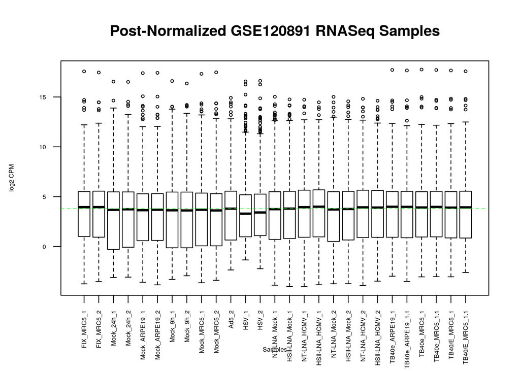

```r
# Draw a box plot of the post-normalized data
logPostNormData <- log2(edgeR::cpm(counts_normalized[, 4:dim(counts_normalized)[2]]))
boxplot(logPostNormData, xlab = "Samples", ylab = "log2 CPM",
        las = 2, cex = 0.5, cex.lab = 0.5,
        cex.axis = 0.5, main = "Post-Normalized GSE120891 RNASeq Samples")
abline(h = median(apply(logPostNormData, 2, median)), col = "green", lwd = 0.6, lty = "dashed")
```

As there was not very much variability between the samples in the first place, the post-normalized box plot appears quite similar to the pre-normalized box plot. However, the distribution of each group appears to be roughly in the same range, which indicates successful normalization.

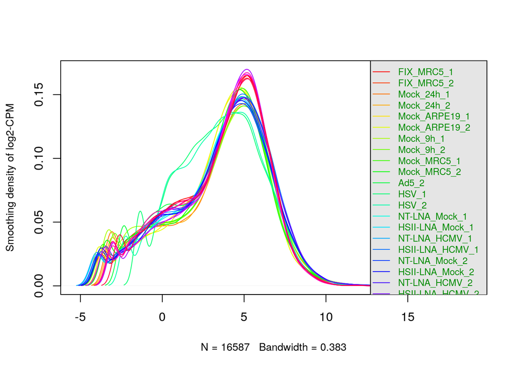

```r
# Draw a density plot of the post-normalized data
post_counts_density <- apply(log2(edgeR::cpm(counts_normalized[, 4:dim(counts_normalized)[2]])), 2, density)

# calculate the limits across all the samples
xlim <- 0; ylim <- 0
for (i in 1:length(post_counts_density)) {
  xlim <- range(c(xlim, post_counts_density[[i]]$x));
  ylim <- range(c(ylim, post_counts_density[[i]]$y))
}
cols <- rainbow(length(post_counts_density))
ltys <- rep(1, length(post_counts_density))
#plot the first density plot to initialize the plot
plot(post_counts_density[[1]], xlim=xlim, ylim=ylim, type="n",
     ylab="Smoothing density of log2-CPM", main="", cex.lab = 0.85)
#plot each line
for (i in 1:length(post_counts_density)) lines(post_counts_density[[i]], col=cols[i], lty=ltys[i])
#create legend
legend("topright", colnames(logPostNormData),
       col=cols, lty=ltys, cex=0.75,
       border ="blue",  text.col = "green4",
       merge = TRUE, bg = "gray90")
```

Just as in the box plot, the density plot has not changed substantially either (as the original density plot was not highly variant in the first place). Nonetheless it can be observed that the distribution near the lower values of log-counts per million is slightly more clustered and regular than from before normalization; most of the variation itself is now in the actual shape of the distributions, as is desired.

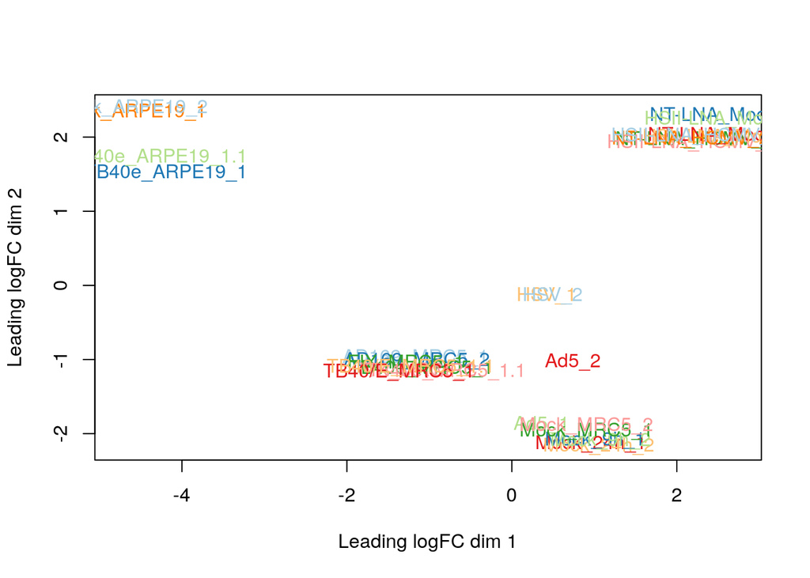

```r
# Draw MDS plot of data
limma::plotMDS(d_normFactors, col = c(RColorBrewer::brewer.pal(n = 8, name = "Paired"),
                                      RColorBrewer::brewer.pal(n = 7, name = "Paired")))
```